# Comparing the overlap of top genes for each metaprogram

Ally Hawkins

2026-03-17

This notebook evaluates the overlap in the top genes across metaprograms. Here we look specifically at the top 200 genes since those are the ones we use for scoring and for running ORA.

**Note:** The code in this notebook has not been optimized as we are not planning to move forward with this metric.

```r
library(ggplot2)

# Set default ggplot theme
theme_set(
  theme_bw()
)

set.seed(2026)
```

## Set Up

```r
# source extract_top_genes()
source(\utils/ora-helper-functions.R\)
```

```r
# metaprograms results directory
results_dir <- here::here(\ews-nf-out\, \metaprograms\)

# params we are looking at in this particular notebook
# use these to construct the file paths
n_metaprograms <- seq(5, 30, 1)

# directories with metaprogram results
# one directory per n_metaprogram
metaprogram_output_dirs <- file.path(
  results_dir,
  glue::glue(\metaprograms-{n_metaprograms}_cnmf-5-10-15_filtered\)
)

# path to files with each of the metrics
metrics_files <- file.path(metaprogram_output_dirs, \metaprograms-metrics.rds\) |>
  purrr::set_names(sprintf(\k_%02d\, n_metaprograms))

# path to files for the actual objects
# we'll use these for re-running ORA
metaprogram_files <- file.path(metaprogram_output_dirs, \metaprograms.rds\) |>
  purrr::set_names(sprintf(\k_%02d\, n_metaprograms))

# path to just one of the metaprogram objects
# we'll use this to get the background gene list which is the same for all values of k
mp_object_file <- metaprogram_files[[1]]

# significance value so we don't accidentally mis type it
sig_value <- 0.05

# number of reps for calculating gene set overlaps
nreps <- 10000
```

```r
# get the metrics files
mp_metrics_list <- metrics_files |>
  purrr::map(readr::read_rds)

# create dataframe with one row per metaprogram/n_metaprogram (k) combination
# each column is a metric for that metaprograms
mp_metrics_df <- mp_metrics_list |>
  purrr::map(\mp_metrics_df\) |>
  dplyr::bind_rows(.id = \n_metaprograms\)

# get a vector of all genes in the universe
gene_universe <- readr::read_rds(mp_object_file)[[\gene_universe\]]
```

## Permute Jaccard similarity index

Ideally, metaprograms show similar overlap to what may be observed by chance when calculating the overlap between two sets of 200 genes from our gene universe. To test this, we’ll create a background distribution where we randomly select two lists of 200 genes and compute the Jaccard similarity index between those lists. We can then ask whether or not the observed Jaccard between the top 200 genes for two metaprograms is significantly greater than the background distribution or not.

Since we are looking at metaprograms calculated from the same set of samples, we only have one gene list and can make just one background distribution.

```r
# function to randomly select sets of 200 genes and calculate the overlap
# compare gene sets using the jaccard similarity index
permute_jaccard <- function(gene_universe, nreps){

  background <- replicate(
    nreps, {

      vec1 <- sample(gene_universe, 200)
      vec2 <- sample(gene_universe, 200)

      jaccard <- length(intersect(vec1, vec2)) / length(union(vec1, vec2))
    }
  )

  return(background)

}
```

```r
# get a single vector of the background values for the jaccard index
background_jaccard <- permute_jaccard(gene_universe, nreps)

# put it into a data frame with column for n_metaprograms and column for background value
# each background value should be repeated for each metaprogram
background_df <- data.frame(
  \n_metaprograms\ = rep(names(metaprogram_files), each = length(background_jaccard)),
  \background_value\ = rep(background_jaccard, length(n_metaprograms))
)
```

Now we’ll calculate the Jaccard similarity index for all possible pairs of the observed metaprograms and compare to the background distribution.

```r
# helper function for getting jaccard between two vectors
calc_jaccard <- function(vec1, vec2) {
  length(intersect(vec1, vec2)) / length(union(vec1, vec2))
}

# get the Jaccard for all possible pairs of metaprograms
all_pair_jaccards <- metaprogram_files |>
  purrr::map(\(file){
    mp_object <- readr::read_rds(file)

    # get list of top genes for each mp
    top_genes <- extract_top_genes(mp_list = mp_object$metaprogram_list)

    jaccard_df <- tidyr::expand_grid(metaprogram1 = names(top_genes), metaprogram2 = names(top_genes)) |>
      dplyr::filter(metaprogram1 != metaprogram2) |>
      # add a column to indicate the pair ID
      dplyr::mutate(
        pair_id = purrr::map2_chr(metaprogram1, metaprogram2, \(a, b) paste(sort(c(a, b)), collapse = \_\))
      ) |>
      # for now remove the duplicate pairs
      # this makes the testing faster but then we'll look at all possible pairs for each metaprogram after pvalue
      dplyr::distinct(pair_id, .keep_all = TRUE) |>
      dplyr::rowwise() |>
      # calculate a single Jaccard index for each combination using split lists & ids
      dplyr::mutate(jaccard = calc_jaccard(top_genes[[metaprogram1]], top_genes[[metaprogram2]])) |>
      dplyr::ungroup() # remove rowwise setting

  }) |>
  dplyr::bind_rows(.id = \n_metaprograms\)
```

Once we have our background distribution, we’ll get a single pvalue for each pair of metaprograms for each value of k. Good metaprograms should *not* be significant and have overlap similar to the background distribution.

```r
# add the background observations to the main metrics dataframe
# get a pvalue for each possible pair on if the observed jaccard is > background
pvalue_df <- all_pair_jaccards |>
  dplyr::left_join(background_df, by = c(\n_metaprograms\)) |>
  dplyr::mutate(
    greater_than_obs = background_value >= jaccard
  ) |>
  dplyr::summarize(
    jaccard = unique(jaccard),
    overlap_pvalue = (sum(greater_than_obs) + 1) / (nreps + 1),
    .by = c(\n_metaprograms\, \metaprogram1\, \metaprogram2\, \pair_id\)
  ) |>
  # add in adjusted pvalue
  dplyr::mutate(
    overlap_adj_pvalue = p.adjust(overlap_pvalue, method = \BH\),
    is_significant = overlap_adj_pvalue <= sig_value
  )
# now mirror the pairs so each MP sees all its comparisons
pvalue_df <- dplyr::bind_rows(
  pvalue_df,
  dplyr::rename(pvalue_df, metaprogram1 = metaprogram2, metaprogram2 = metaprogram1)
)
```

Here we’ll plot the Jaccard for each pair in relationship to the background distribution. Each colored point indicates a pair of metaprograms for a single value of k.

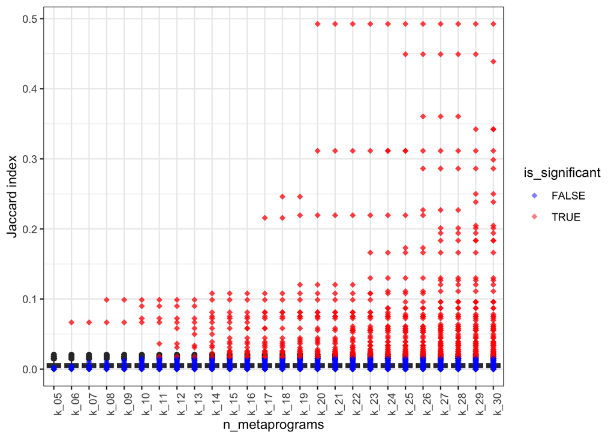

```r
ggplot(background_df, aes(x = n_metaprograms, y = background_value)) +
  geom_boxplot() +
  geom_point(
    data = pvalue_df,
    aes(
      x = n_metaprograms,
      y = jaccard,
      color = is_significant
    ),
    size  = 2,
    alpha = 0.5,
    shape = 18  # diamond
  ) +
  scale_color_manual(values = c(`TRUE` = \red\, `FALSE` = \blue\)) +
  labs(
    y = \Jaccard index\
  ) +
  theme(
    axis.text.x = element_text(angle = 90)
  )
```

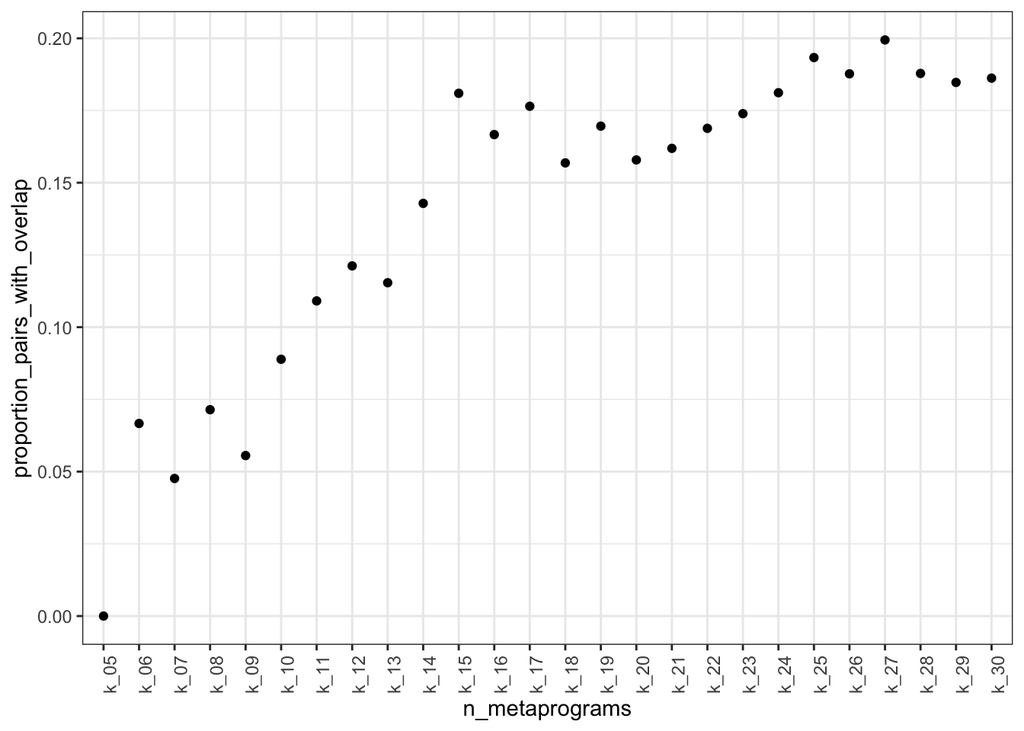

```r
proportion_df <- pvalue_df |>
  dplyr::summarize(
    num_pairs = length(pair_id),
    proportion_pairs_with_overlap = sum(is_significant)/num_pairs,
    .by = c(\n_metaprograms\)
  )

ggplot(proportion_df, aes(x = n_metaprograms, proportion_pairs_with_overlap)) +
  geom_point() +
  theme(
    axis.text.x = element_text(angle = 90)
  )
```

## Median cutoff

Instead of getting a pvalue for each pair, an alternative approach would be to count how many pairs have an observed value above the median in the background distribution. We’ll look at the distribution and color each point if it’s greater than the median or not and then summarize the total proportion of pairs with an observed Jaccard greater than the median.

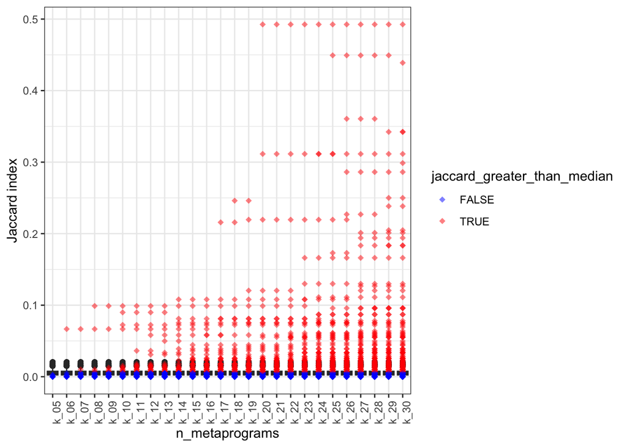

```r
median_background_jaccard <- median(background_jaccard)

# add a column indicating if the value is > median
median_df <- all_pair_jaccards |>
  dplyr::ungroup() |>
  dplyr::mutate(
    jaccard_greater_than_median = jaccard > median_background_jaccard
  )

ggplot(background_df, aes(x = n_metaprograms, y = background_value)) +
  geom_boxplot() +
  geom_point(
    data = median_df,
    aes(
      x = n_metaprograms,
      y = jaccard,
      color = jaccard_greater_than_median
    ),
    size  = 2,
    alpha = 0.5,
    shape = 18  # diamond
  ) +
  scale_color_manual(values = c(`TRUE` = \red\, `FALSE` = \blue\)) +
  labs(
    y = \Jaccard index\
  ) +
  theme(
    axis.text.x = element_text(angle = 90)
  )
```

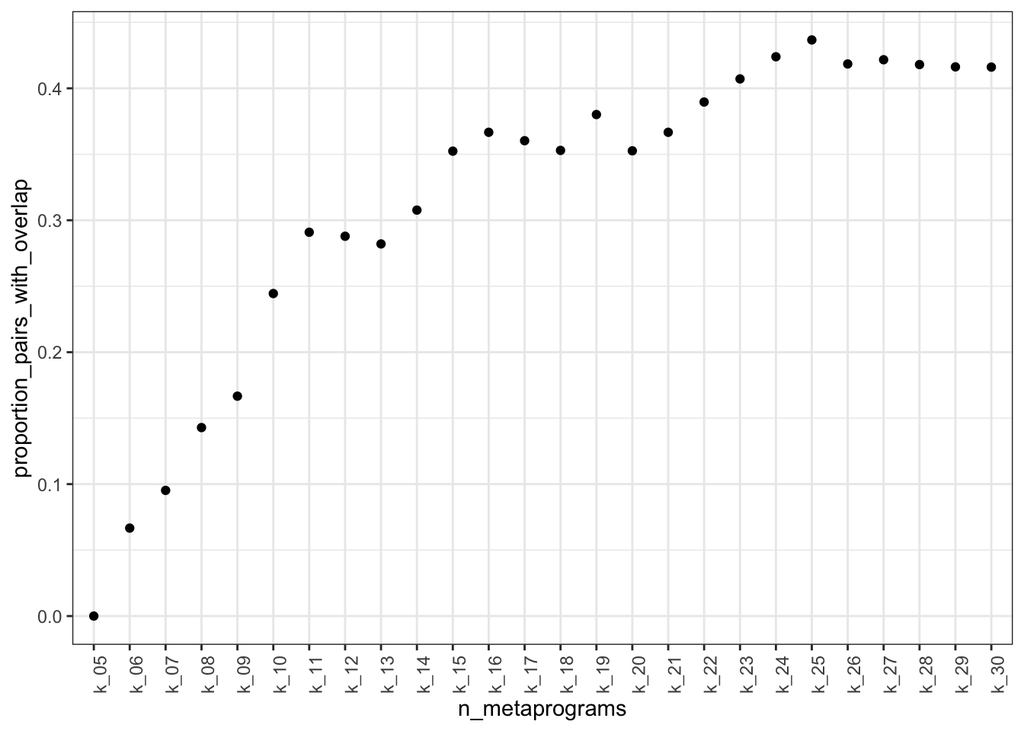

```r
# count how many total pairs for each value of k > median
proportion_median_df <- median_df |>
  dplyr::summarize(
    num_pairs = length(pair_id),
    proportion_pairs_with_overlap = sum(jaccard_greater_than_median)/num_pairs,
    .by = c(\n_metaprograms\)
  )

ggplot(proportion_median_df, aes(x = n_metaprograms, proportion_pairs_with_overlap)) +
  geom_point() +
  theme(
    axis.text.x = element_text(angle = 90)
  )
```

These plot look very similar to the above plots, so I don’t know that there’s a huge difference in the conclusions from these approaches.

## Mean Jaccard

Now, instead of 1 pvalue for each pair, let’s try to get one pvalue for each metaprogram. To do that, we will calculate the mean of all pairs for each metaprogram and then compare the mean to the background to get a pvalue.

```r
# get the mean for each metaprogram
mean_jaccard_df <- pvalue_df |>
  dplyr::summarize(
    mean_jaccard = mean(jaccard),
    .by = c(\n_metaprograms\, \metaprogram1\)
  )

# calculate a pvalue for each observed mean
mean_pvalue_df <- mean_jaccard_df |>
  dplyr::left_join(background_df, by = c(\n_metaprograms\)) |>
  dplyr::mutate(
    greater_than_obs = background_value >= mean_jaccard
  ) |>
  dplyr::summarize(
    mean_jaccard = unique(mean_jaccard),
    overlap_pvalue = (sum(greater_than_obs) + 1) / (nreps + 1),
    .by = c(\n_metaprograms\, \metaprogram1\)
  ) |>
  # add in adjusted pvalue
  dplyr::mutate(
    overlap_adj_pvalue = p.adjust(overlap_pvalue, method = \BH\),
    is_significant = overlap_adj_pvalue <= sig_value
  )
```

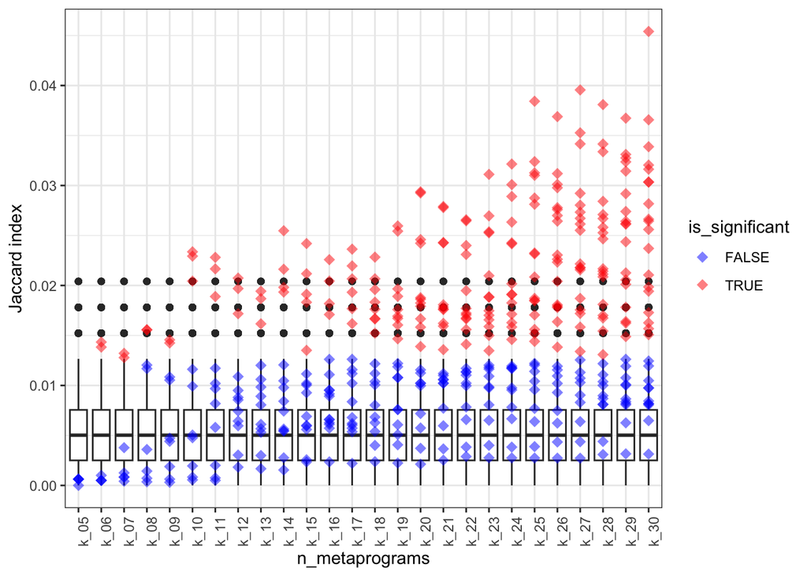

```r
ggplot(background_df, aes(x = n_metaprograms, y = background_value)) +
  geom_boxplot() +
  geom_point(
    data = mean_pvalue_df,
    aes(
      x = n_metaprograms,
      y = mean_jaccard,
      color = is_significant
    ),
    size  = 3,
    alpha = 0.5,
    shape = 18  # diamond
  ) +
  scale_color_manual(values = c(`TRUE` = \red\, `FALSE` = \blue\)) +
  labs(
    y = \Jaccard index\
  ) +
  theme(
    axis.text.x = element_text(angle = 90)
  )
```

Now what if we get the proportion of metaprograms that have a mean Jaccard indicating significant overlap.

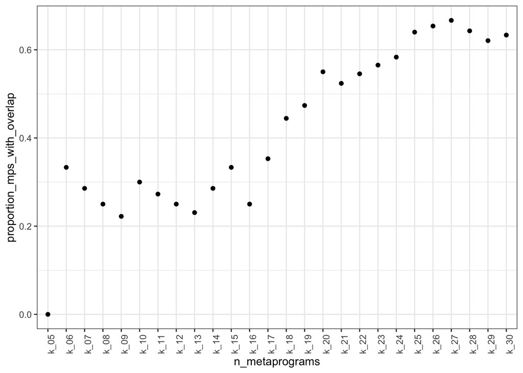

```r
mean_proportion_df <- mean_pvalue_df |>
  dplyr::summarize(
    k = stringr::str_remove(n_metaprograms, \k_\) |>
      as.numeric() |>
      unique(),
    proportion_mps_with_overlap = sum(is_significant)/k,
    .by = c(\n_metaprograms\)
  )

ggplot(mean_proportion_df, aes(x = n_metaprograms, proportion_mps_with_overlap)) +
  geom_point() +
  theme(
    axis.text.x = element_text(angle = 90)
  )
```

This appears to be slightly less dependent on the value of k? The values are in a similar range for k=6 through k=17 and then jump higher for values of k > 17. Again, how much of this is a function of the range from cNMF?

I think we might be able to use any of these approaches and find a cutoff for a maximum value of k, but we probably want to compare this to using the full range of k=5 to k=25.